# Practical Machine Learning Project

Karunesh Arora

May 23, 2015

# Executive Summary

The goal of this project is to use the Weight Lifting Exercises dataset to predict the manner in which participants did the exercise. Data for this excerise was collected from accelerometers on the belt, forearm, arm, and dumbell of 6 participants who were asked to perform barbell lifts correctly and incorrectly in 5 different ways. The data for this project come from this source (http://groupware.les.inf.puc-rio.br/har).

Here, we first downloaded the training and validation data for this project. Following, we cleaned the data, i.e., omitted variables with nearzero variances or that contained mostly “NA” in most rows. Then we the partitioned this cleaned data into the “Test” and “Training” set. Next, we performed explaratory data analysis using Principal Components Analysis (PCA). Finally, we began the fitting process where we first applied the Gradient Boosting Regression Model (GBM) on the training data pre-processed using PCA. This fitting process resulted in accuracy of 0.9199834 and 0.9274 on the the training and the test data set, respectively. We then applied the GBM model on the training data that was NOT pre-processed using PCA. This resulted in much higher accuracy for both the training (0.9900854) and the test (0.9937) set compared to GBM applied to data preprocessed using PCA. Therefore, we applied the GBM model to the 20 test cases available in the validation data and submitted predictions to the programming assignment for automated grading.

```r
require(caret); require(ggplot2);suppressWarnings(require(readr)); suppressWarnings(require(ggbiplot))
```

## Import data

```r
#Import data
# Training data https://d396qusza40orc.cloudfront.net/predmachlearn/pml-training.csv
#Validation data https://d396qusza40orc.cloudfront.net/predmachlearn/pml-testing.csv
suppressWarnings(training_DF<-read_csv("~/Downloads/pml-training.csv",na = "NA"))
suppressWarnings(validation_DF<-read_csv("~/Downloads/pml-testing.csv",na = "NA"))

dim(training_DF)
```

```
## [1] 19622   160
```

```r
dim(validation_DF)
```

```
## [1]  20 160
```

## Cleaning the Imported data

```r
#clean the data
#filter near-zero variance predictors
zerovars<-nearZeroVar(training_DF)
#we choose to only omit columns for which both nzv=="FALSE" and zeroVar=="FALSE"
#Therefore keep "yaw_arm" variable
zerovars<-zerovars[-5]

#omit columns with near zero variance
training_DF<-training_DF[,-zerovars]


# Omit columns with mostly NA values
training_DF<-training_DF[colSums(is.na(training_DF)) == 0]

#omit columns that are not the predictor variables
names(training_DF[1:6])
```

```
## [1] "[EMPTY]"              "user_name"            "raw_timestamp_part_1"
## [4] "raw_timestamp_part_2" "cvtd_timestamp"       "num_window"
```

```r
training_DF<-training_DF[,-c(1:6)]

# Omit "skewness_yaw_belt" that only contains "DIV/0!" garbage characters
training_DF<-training_DF[,-c(5)]

# Make "classe" as factor variable
#needed for data partition based on "classe" below
training_DF$classe<-as.factor(training_DF$classe)

#final dimensions
dim(training_DF)
```

```
## [1] 19622    52
```

## Create data partition into Test and Train based on “classe” variable

```r
#Split into Test and Train
inTrain <- createDataPartition(y = training_DF$classe, p=0.70, list=FALSE)
finaltraining_DF <- training_DF[inTrain, ]
finaltesting_DF <- training_DF[-inTrain, ]
```

## Exploratory data analysis using PCA

```r
#Compute PCs of the training set
pcaObject<-prcomp(finaltraining_DF[sapply(finaltraining_DF,is.numeric)],scale.=TRUE,center=TRUE)
#compute percent variance of each PC
percentVariance <- pcaObject$sd^2/sum(pcaObject$sd^2)*100
```

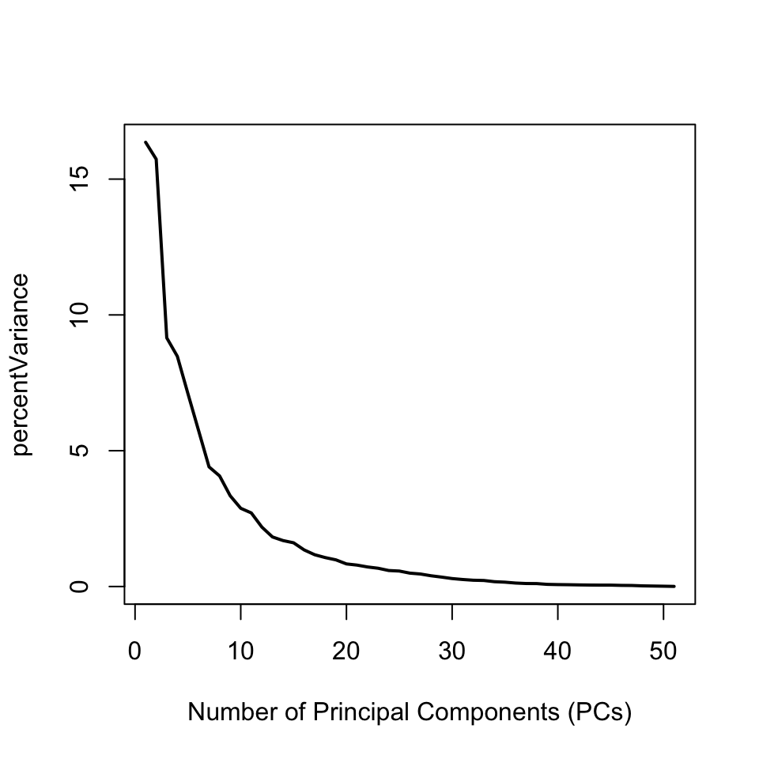

```r
#Plot percent total variance explained by each component
#more than 90% variance of the data explained by 25 PC's
plot(percentVariance ,type='l',xlab="Number of Principal Components (PCs)",cex=1.2,lwd=2)
```

# Pre-process the data with PCA

```r
#train PCA model -center and scale the training set
#compress the training data based on PCA=
procValues<-preProcess(finaltraining_DF[,-52],method=c("center","scale","pca"))

#Apply PCA model to training and test sets
#PCA only applied to numeric columns and not to "classe"
trainScaled<-predict(procValues,finaltraining_DF[,-52])
testScaled<-predict(procValues,finaltesting_DF[,-52])

#Add "classe" factor variable back to dataframe
trainScaled$classe<-finaltraining_DF$classe
testScaled$classe<-finaltesting_DF$classe
```

# Generalized Boosted Regression Model (GBM)

We first tuned the parameters n.trees, shrinkage and interaction.depth before applying this model to training set (see below).

## Tuning the parameters in GBM

```r
#The trainControl function to set the training method
# Cross-Validated (10 fold, repeated 5 times)
ctrl<-trainControl(method="repeatedcv",
                   repeats=5,
                   number = 10,
                   classProbs = TRUE)

#Use the expand.grid to specify the search space
gbmGrid <-  expand.grid(interaction.depth = seq(1,9,by=2),
                        n.trees = seq(1, 500, by=100),
                        shrinkage = c(0.01,0.1),
                        n.minobsinnode = 10)

#run job in parallel
require(doMC)
registerDoMC(cores=5)

#Run the train function
set.seed(1)
system.time(gbm.tune <- train(classe ~ ., data = trainScaled,
                 method = "gbm",
                 verbose = FALSE,
                 tuneGrid = gbmGrid,
                 trControl = ctrl))
gbm.tune
```

[output not shown]

## GBM model predictions using tuned parameters applied to data pre-processed with PCA

```r
fitControl <- trainControl(## 10-fold CV
  method = "repeatedcv",
  number = 10,
  ## repeated five times
  repeats = 5,
  classProbs = TRUE)

#run job in parallel
require(doMC)
registerDoMC(cores=5)

set.seed(825)
gbmFit1 <- train(trainScaled$classe ~ ., data = trainScaled,
                 method = "gbm",
                 trControl = fitControl,
                tuneGrid = data.frame(interaction.depth = 7,
                                       n.trees = 200,
                                       shrinkage = 0.1,
                                       n.minobsinnode = 10),
                                       verbose = FALSE)
gbmFit1
```

```r
#result from executing gbmFit1
#I ran these jobs in parallel on terminal.
#Rstudio kept crashing. Therefore I had to copy results
#from the terminal to the markdown document.

Stochastic Gradient Boosting

13737 samples
   24 predictor
    5 classes: 'A', 'B', 'C', 'D', 'E'

No pre-processing
Resampling: Cross-Validated (10 fold, repeated 5 times)

Summary of sample sizes: 12363, 12363, 12363, 12364, 12364, 12364, ...

Resampling results

  Accuracy   Kappa      Accuracy SD  Kappa SD
  0.9199834  0.8987348  0.008013277  0.0101495

Tuning parameter 'n.trees' was held constant at a value of 200

Tuning parameter 'shrinkage' was held constant at a value of 0.1

Tuning parameter 'n.minobsinnode' was held constant at a value of 10
```

Check the performance of the model. Apply predict function on the test set and print the confusion matrix.

```r
model_1<-predict(gbmFit1,testScaled)
confusionMatrix(testScaled$classe,model_1)
```

```r
Confusion Matrix and Statistics

          Reference
Prediction    A    B    C    D    E
         A 1625   24    7   15    3
         B   67 1003   45    9   15
         C    8   40  954   16    8
         D    8   10   71  865   10
         E    6   23   20   22 1011

Overall Statistics

               Accuracy : 0.9274
                 95% CI : (0.9205, 0.9339)
    No Information Rate : 0.2912
    P-Value [Acc > NIR] : < 2.2e-16

                  Kappa : 0.9082
 Mcnemar's Test P-Value : 4.514e-11
```

Results show that accuracy of the model applied to the test set is 0.9274. Therefore, the out of sample error is (1-0.9274)=.0726, i.e., 7.26%.

## GBM model predictions applied to training data without any prior pre-processing with PCA

We applied GBM to training data without any pre-processing. The goal was to check if compressing the variables using PCA influences the accuracy of the results.

```r
#run job in parallel
require(doMC)
registerDoMC(cores=5)

set.seed(825)
gbmFit2 <- train(finaltraining_DF$classe ~ ., data = finaltraining_DF,
                 method = "gbm",
                 trControl = fitControl,
                 tuneGrid = data.frame(interaction.depth = 7,
                                       n.trees = 200,
                                       shrinkage = 0.1,
                                       n.minobsinnode = 10),
                                       verbose = FALSE)
gbmFit2
```

Clearly, results below show that the accuracy of the results increased significantly (0.9900854) when GBM was applied to the training data that was not pre-processed with PCA.

```r
Stochastic Gradient Boosting

13737 samples
   51 predictor
    5 classes: 'A', 'B', 'C', 'D', 'E'

No pre-processing
Resampling: Cross-Validated (10 fold, repeated 5 times)

Summary of sample sizes: 12363, 12363, 12363, 12364, 12364, 12364, ...

Resampling results

  Accuracy   Kappa      Accuracy SD  Kappa SD
  0.9900854  0.9874601  0.003019812  0.003819212

Tuning parameter 'n.trees' was held constant at a value of 200
Tuning

Tuning parameter 'shrinkage' was held constant at a value of 0.1

Tuning parameter 'n.minobsinnode' was held constant at a value of 10
```

Applying predict function on the test data showed that the out of sample accuracy is 0.9937. Therefore, out sample error is (1-0.9937 )= .0063 or 0.63 %

```r
model_2<-predict(gbmFit2,finaltesting_DF)
confusionMatrix(finaltesting_DF$classe,model_2)
```

```r
Confusion Matrix and Statistics

          Reference
Prediction    A    B    C    D    E
         A 1670    4    0    0    0
         B    3 1132    4    0    0
         C    0    9 1016    1    0
         D    0    1    6  955    2
         E    0    1    3    3 1075

Overall Statistics

               Accuracy : 0.9937
                 95% CI : (0.9913, 0.9956)
    No Information Rate : 0.2843
    P-Value [Acc > NIR] : < 2.2e-16

                  Kappa : 0.992
 Mcnemar's Test P-Value : NA
```

Show the relative importance of the variables the final trained model “gbmFit2”.

```r
gbmImp<-varImp(gbmFit2, scale = TRUE)
gbm variable importance

  only 20 most important variables shown (out of 51)

                  Overall
roll_belt         100.000
yaw_belt           61.946
pitch_forearm      54.325
magnet_dumbbell_z  38.568
magnet_dumbbell_y  31.744
pitch_belt         28.738
roll_forearm       27.500
magnet_belt_z      26.542
accel_dumbbell_y   15.555
gyros_belt_z       14.238
accel_forearm_z    13.563
roll_dumbbell      12.774
magnet_forearm_z   12.738
magnet_dumbbell_x  12.581
accel_forearm_x    12.255
accel_dumbbell_x    9.370
gyros_dumbbell_y    9.359
magnet_forearm_x    8.012
magnet_arm_z        7.726
magnet_belt_x       7.681
```

Finally, gbmFit2 was applied to the 20 test cases available in the validation data and submitted predictions to the programming assignment for automated grading.

```r
predict(gbmFit2,validation_DF)
 [1] B A B A A E D B A A B C B A E E A B B B
Levels: A B C D E
```

# Conclusions

Our results show that GBM model with tuned parameters when applied to data that is not pre-processed using PCA gave very high accuracy close to 99% with out-of-sample error less than 1%.